# Analysis of RNA-seq data in R and Bioconductor

Rockefeller University, Bioinformatics Resource Centre

http://rockefelleruniversity.github.io/RU_RNAseq/

## The data.

In this session we will be reviewing data from Christina Leslie’s lab at MSKCC on T-Reg cells and activated T-Reg cells. T-Reg data can be found on the Encode portal [here](https://www.encodeproject.org/experiments/ENCSR486LMB/) and activated T-Reg data [here](https://www.encodeproject.org/experiments/ENCSR726DNP/)

I have aligned all FQ to BAM and counted in genes and exons using Rsubread and summariseOverlaps().

I have also quantified our transcripts from FQ files using our transcript fasta from last session and Salmon.

## What we will cover.

In our first session we will looked at two separate ways we can gain gene expression estimates from raw sequencing data as fastQ files.

In our last session we imported our expression estimates to identify differences in the expression of genes between two conditions.

In this session we will look at how we can identify differences in the expression of genes between multiple conditions and how we can identify changes in Exon usage to infer changes in transcript usage.

## Counts from SummariseOverlaps

For differential exon usage we must use a non-overlapping,disjoint set of exons to count on.

We can produce a non-overlapping set of exons by using the **disjointExons()** function. This is equivalent of us having to create GFF file and using the python script wrapped up in DEXseq package (*dexseq_prepare_annotation.py*).

```r
library(GenomicFeatures)
nonOverlappingExons <- disjointExons(TxDb.Mmusculus.UCSC.mm10.knownGene)
names(nonOverlappingExons) <- paste(mcols(nonOverlappingExons)$gene_id,
                                    mcols(nonOverlappingExons)$exonic_part,
                                    sep="_")
nonOverlappingExons[1:2,]
```

```
## GRanges object with 2 ranges and 3 metadata columns:
##               seqnames               ranges strand |         gene_id
##                  <Rle>            <IRanges>  <Rle> | <CharacterList>
##   100009600_1     chr9 [21062393, 21062717]      - |       100009600
##   100009600_2     chr9 [21062894, 21062987]      - |       100009600
##                             tx_name exonic_part
##                     <CharacterList>   <integer>
##   100009600_1 uc009veu.1,uc033jjg.1           1
##   100009600_2 uc009veu.1,uc033jjg.1           2
##   -------
##   seqinfo: 66 sequences (1 circular) from mm10 genome
```

## Disjoint Exons

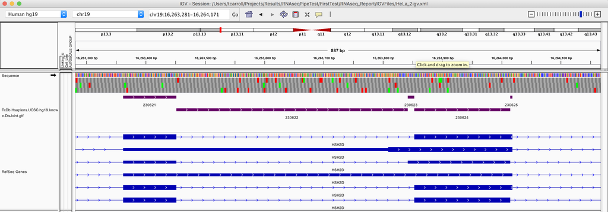

## Counts from SummariseOverlaps

Our **RangedSummarizedExperiment** contains our counts as a matrix accessible by the **assay()** function.

Each row is named by our Exon ID, geneID + exon number.

```r
assay(tregExonCounts)[1:2,]
```

```
##             Sorted_T_reg_act_1.bam Sorted_T_reg_1.bam
## 100009600_1                      0                  1
## 100009600_2                      2                  0
##             Sorted_T_reg_act_2.bam Sorted_T_reg_2.bam
## 100009600_1                      2                  1
## 100009600_2                      0                  1
##             Sorted_T_reg_act_3.bam
## 100009600_1                      4
## 100009600_2                      0
```

## Differential transcript usage from RNAseq data.

Previously we have investigated how we may identify changes in the overall abundance on gene.

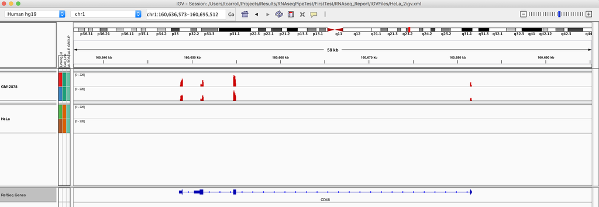